# ggplot2r4ds

the statement gives error as we have not specified x and y axes-what will be drawn on these axes is not written and so we can use some geom method on an empty canvas which is created by ggplot(data) statement

step1:make a new canvas using ggplot()

step2:make axes/squares on the 2d graph by using x and y coordinates and specifying columns of data set

step3:specify what we wanna do with these values of both the columns using some geom method

question 6

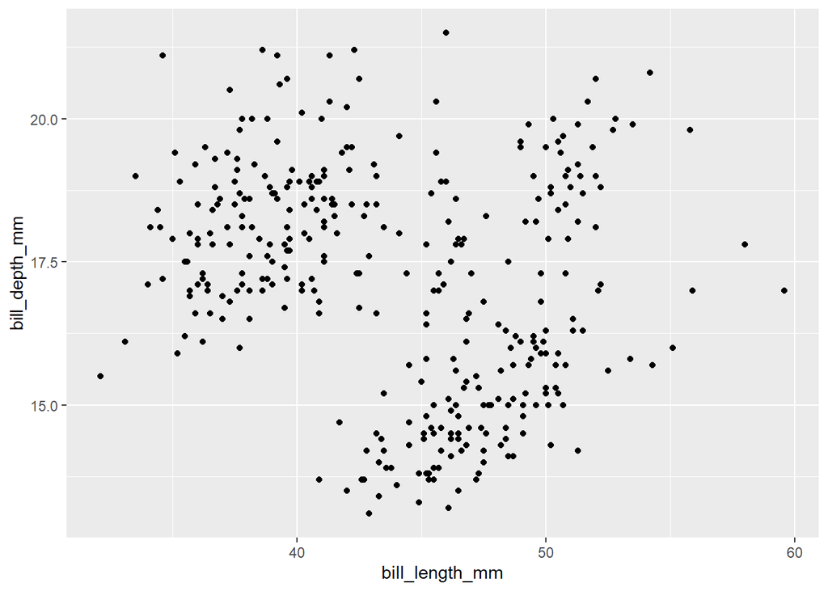

```r
ggplot(data=penguins,mapping=aes(x=bill_length_mm,y=bill_depth_mm))+geom_point(na.rm=TRUE)
```

if false-the empty values are removed with a warning while if true the empty values are removed without a warning

default=false

link to website: https://stackoverflow.com/questions/58443566/what-does-na-rm-true-actually-means

question7

link to website: https://www.rdocumentation.org/packages/ggplot2/versions/3.4.2/topics/labs

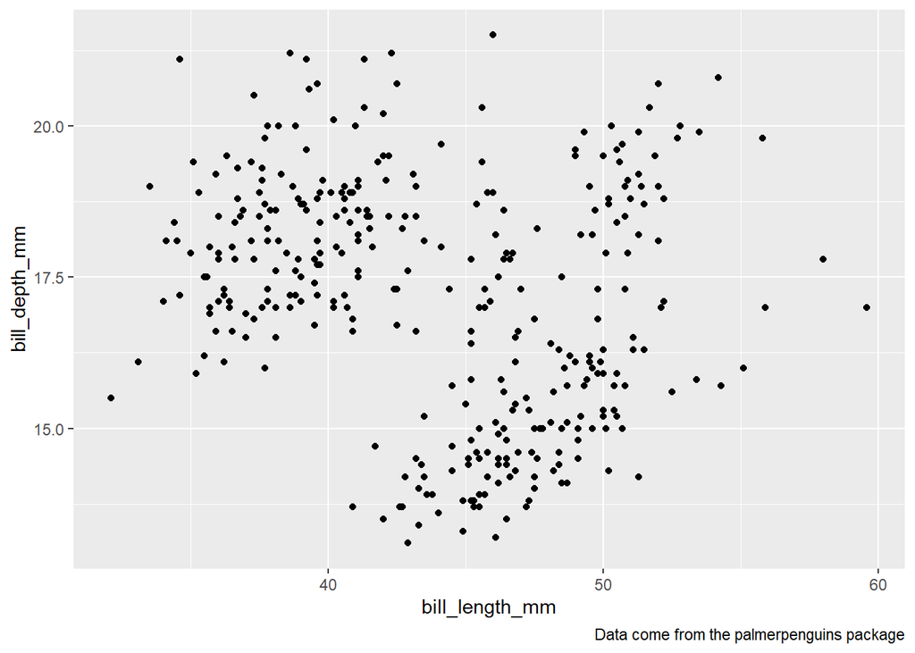

```r
ggplot(data=penguins,mapping=aes(x=bill_length_mm,y=bill_depth_mm))+geom_point(na.rm=TRUE)+labs(caption="Data come from the palmerpenguins package")
```

question8

using at local level as we want dots of different shapes but line should not be broken into different segments like dots

so we use local just to separate dots into different categories rather than global where we separate both dots and lines into separate categories

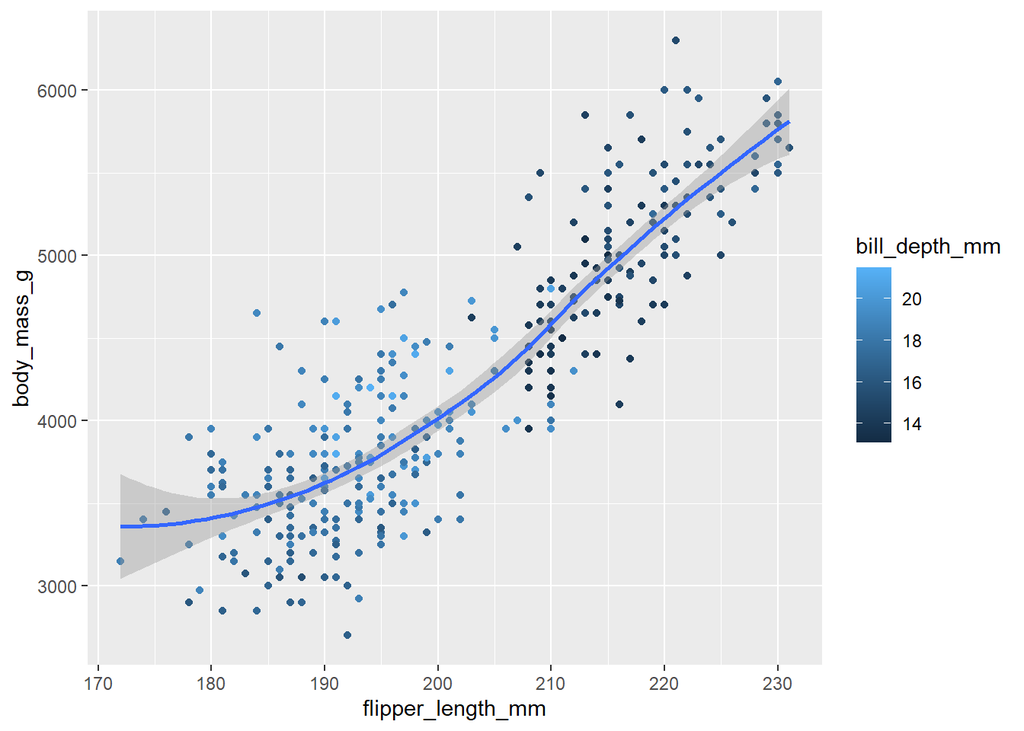

```r
ggplot(data=penguins,mapping=aes(x=flipper_length_mm,y=body_mass_g))+geom_point(aes(color=bill_depth_mm))+geom_smooth()
```

question 9

answer:using x and y columns and color of dots of scatter plot or any other geom style is dependent on type of value of island column

the color aesthetics is applicable to global settings of the canvas on which we are making the geom graphs(both smooth and point in this case) and also we don’t get to see line of standard error with smooth curve(the grey line is removed by se=FALSE)

so different colored points and different colored separate broken lines without grey areas

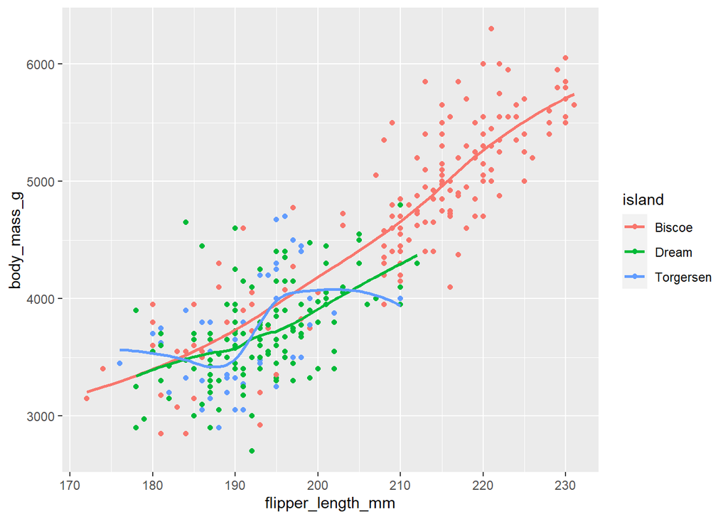

```r
ggplot(
  data = penguins,
  mapping = aes(x = flipper_length_mm, y = body_mass_g, color = island)
) +
  geom_point() +
  geom_smooth(se = FALSE)
```

question 10

answer:the two graphs will look same as in first graph we apply aesthetics settings on global scale while in second graph,we apply the settings separately to both or all of the geom methods we use

RULE:it is better to use data into ggplot() method and these use simultaneous mapping and aesthetics in different geom objects rather than use data in every geom object and leave ggplot() empty

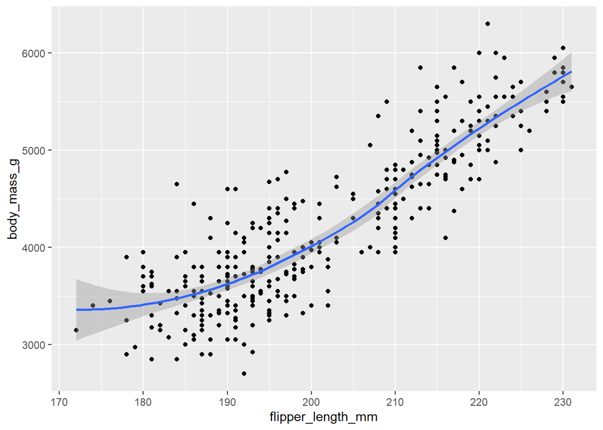

```r
ggplot(
  data = penguins,
  mapping = aes(x = flipper_length_mm, y = body_mass_g)
) +
  geom_point() +
  geom_smooth()
```

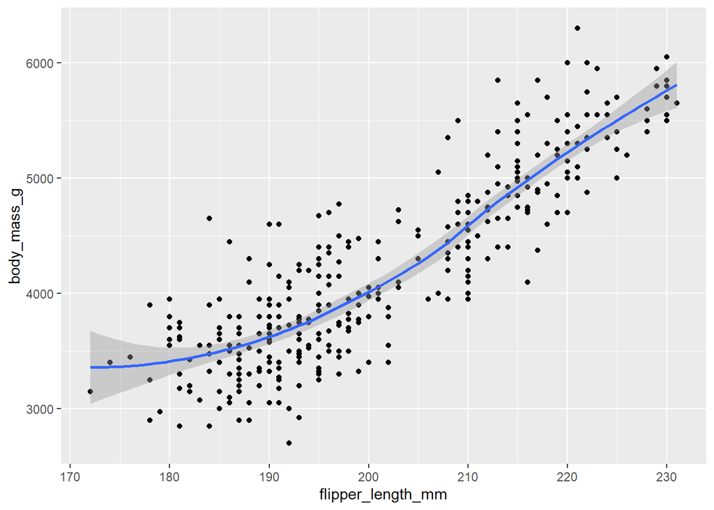

```r
ggplot() +
  geom_point(
    data = penguins,
    mapping = aes(x = flipper_length_mm, y = body_mass_g)
  ) +
  geom_smooth(
    data = penguins,
    mapping = aes(x = flipper_length_mm, y = body_mass_g)
  )
```

question 11 and 12

answer:we get reverse bar plot where count is on x axis

color is for boundaries of bars while fill fills inside the bars’ boundaries

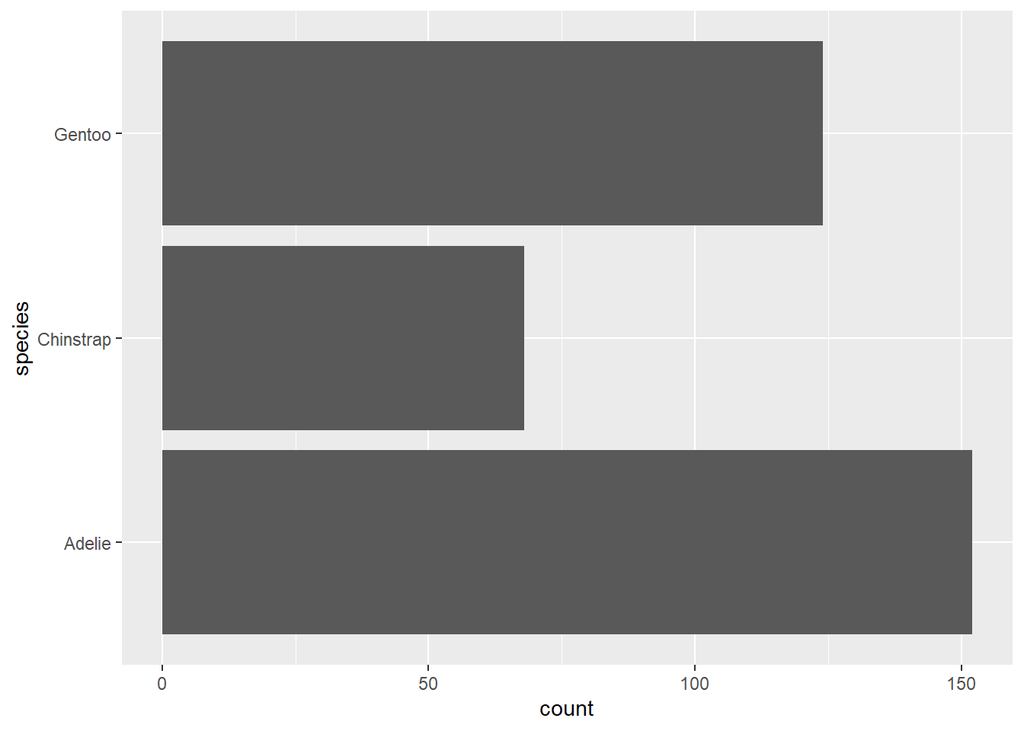

```r
ggplot(data=penguins,mapping=aes(y=species))+geom_bar()
```

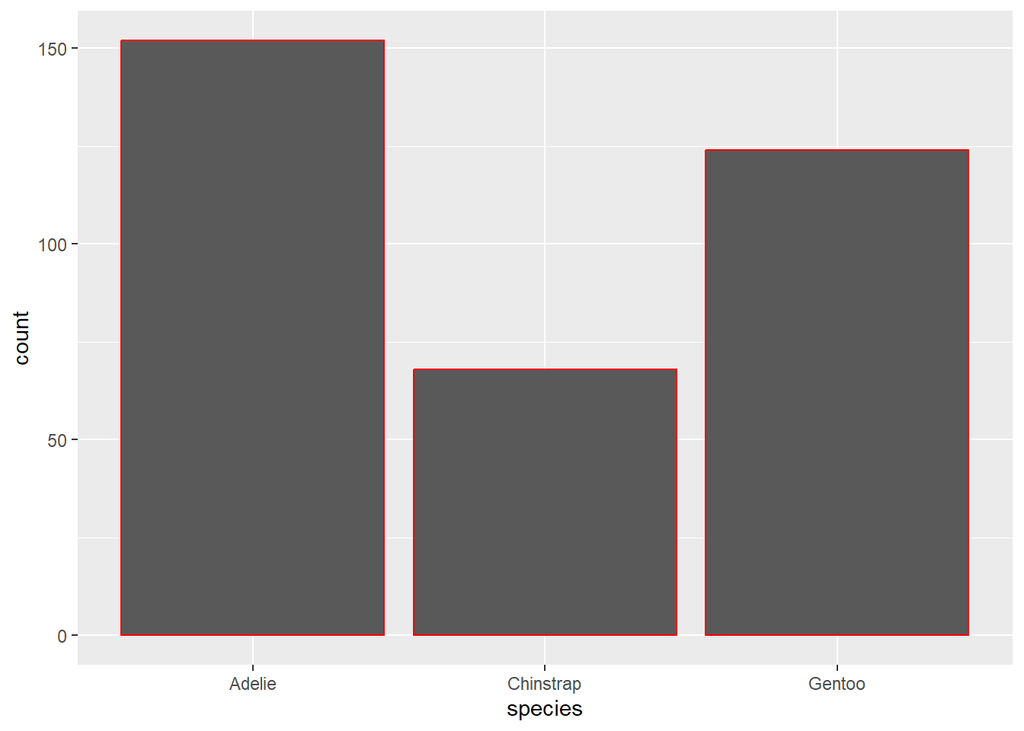

```r
ggplot(penguins, aes(x = species)) +
  geom_bar(color = "red")
```

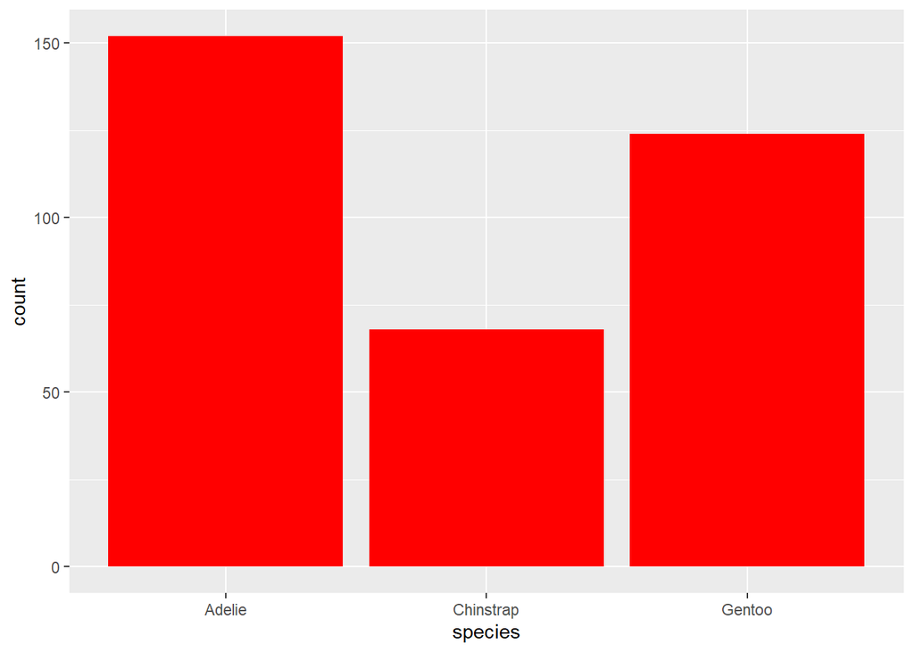

```r
ggplot(penguins, aes(x = species)) +
  geom_bar(fill = "red")
```

question 13

bins is overwritten by binwidth and default bin value is 30(we get to choose how to evenly divide bars/values into equally sized bins-more the bins,lesser the width)

number of bins is indirectly proportional to binwidth of each bin